# Dis Manibus Segregation in RE

In this exercise you will map the ancient equivalent of Twitter data: the ancient inscriptions. Ancient people of class, education, and means liked to advertise their achievements and life milestones as well as their sorrows via the means of texts inscribed in stone. These epigraphic monuments were often placed near inhabited areas, roads, and gathering places where they were likely to attract the largest audience. The location of these self-expressions in space and time is a reasonable indicator of changing economic prosperity of the commissioning communities. In this exercise, you will explore how these ancient inscriptions spatially correspond to the distribution of ancient cities and settlements.

# Task 1: Get spatial data for Roman Provinces

```r
provinces <- st_read("https://raw.githubusercontent.com/pelagios/magis-pleiades-regions/main/pleiades-regions-magis-pelagios.geojson")
```

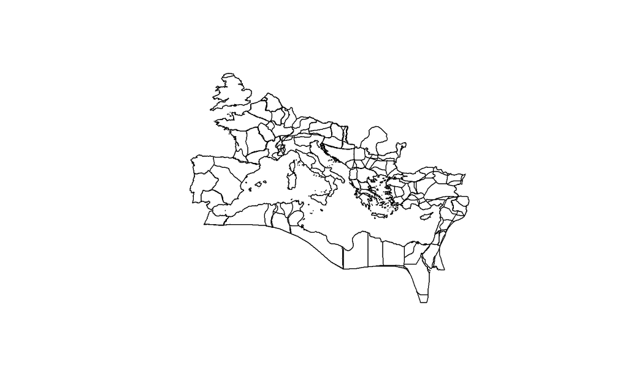

```r
plot(provinces$geometry)
```

```r
unique(provinces$name) %>%
    sort()
```

```
 [1] "Achaia"                   "Aegyptus"
 [3] "Aegyptus Herculia"        "Aegyptus Iovia"
 [5] "Aemilia et Liguria"       "Africa"
 [7] "Africa Proconsularis"     "Alpes Cottiae"
 [9] "Alpes Graiae et Poeninae" "Alpes Maritimae"
[11] "Apulia et Calabria"       "Aquitania"
[13] "Aquitania I"              "Aquitania II"
[15] "Arabia"                   "Armenia Minor"
[17] "Asia"                     "Asiana"
[19] "Augusta Euphratensis"     "Augusta Libanensis"
[21] "Baetica"                  "Belgica"
[23] "Belgica I"                "Belgica II"
[25] "Bithynia"                 "Bithynia et Pontus"
[27] "Britannia"                "Britanniae"
[29] "Byzacena"                 "Campania"
```

[output cut: 24 more lines]

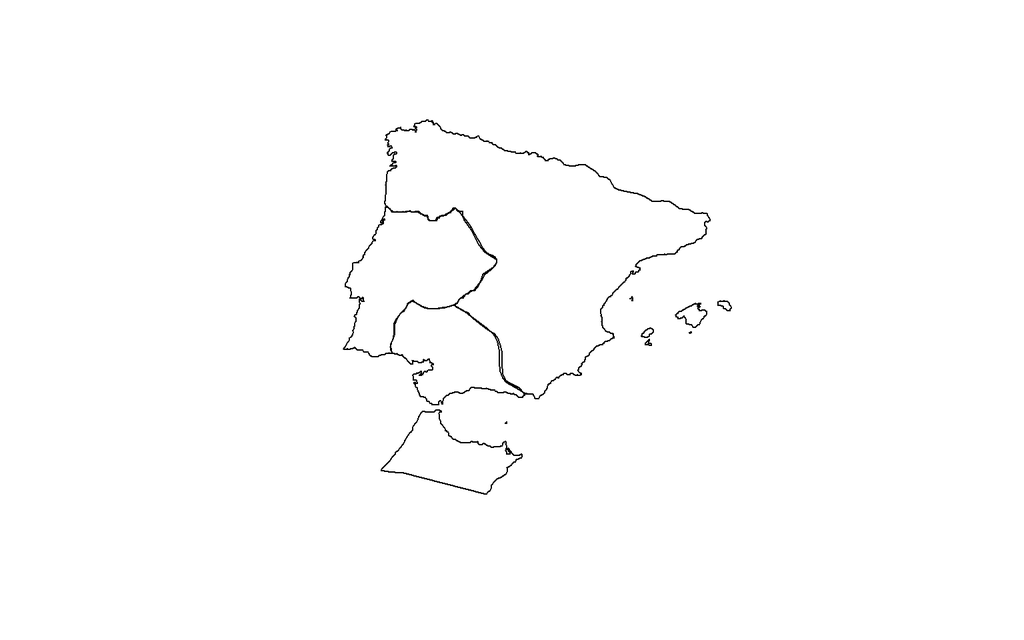

```r
Spain <- provinces %>%
    filter(name %in% c("Lusitania", "Baetica", "Hispaniae")) %>%
    st_transform(3035)
plot(Spain$geometry)
```

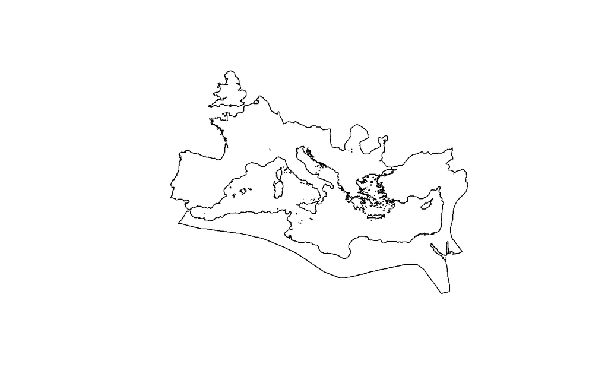

```r
RE <- st_union(provinces) %>%
    st_transform(3035)
plot(RE)
```

# Task 2: Load DM inscriptions

## Load DM inscriptions from the entire Empire

We could load the formulas for the entire Empire, but they are a bit unwieldy for the purpose of segregation, so let us instead start with the inscriptions in Spain.

```
# A tibble: 6 x 80
  responsible_ind~ type_of_inscrip~ letter_size not_after literature work_status
  <chr>            <chr>            <chr>       <chr>     <chr>      <chr>
1 Feraudi          epitaph          3.2-2 cm    0130      AE 1983, ~ provisional
2 Gräf             epitaph          7-4 cm      0150      AE 1983, ~ checked wi~
3 Feraudi          epitaph          4-2 cm      0200      AE 1983, ~ provisional
4 Gräf             epitaph          4.2-2.5 cm  0200      AE 1983, ~ checked wi~
5 Feraudi          epitaph          2-1.5 cm    0300      AE 1983, ~ provisional
6 Feraudi          epitaph          <NA>        0150      AE 1983, ~ checked wi~
# ... with 74 more variables: height <chr>, diplomatic_text <chr>,
#   people <list>, depth <chr>, material <chr>, type_of_monument <chr>,
#   province_label <chr>, width <chr>, transcription <chr>, country <chr>,
#   uri <chr>, findspot_ancient <chr>, last_update <chr>, modern_region <chr>,
#   findspot_modern <chr>, language <chr>, id <chr>, edh_geography_uri <chr>,
#   commentary <chr>, trismegistos_uri <chr>, not_before <chr>,
#   external_image_uris <list>, fotos <list>, longitude <dbl>, ...
```

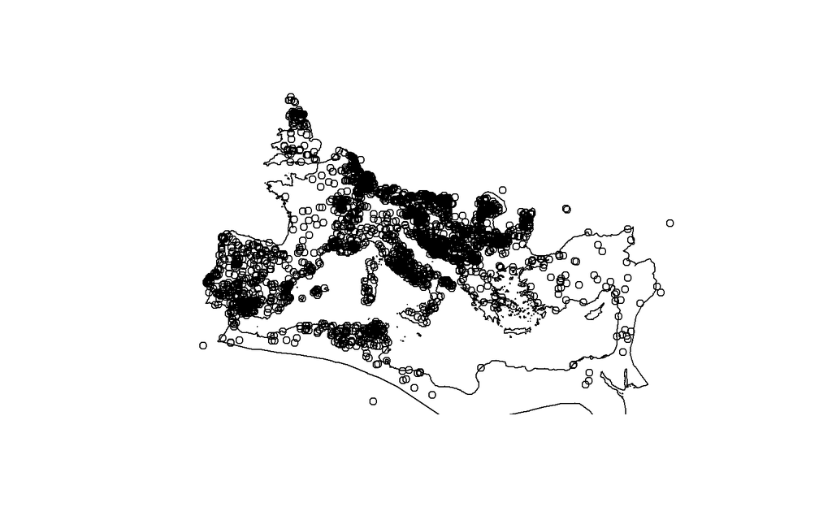

## Get Spain for test

```r
# Get just Spain
library(tidyverse)

# On Home Dell inscriptions <-
# read_csv('C:/Users/Adela/Documents/RStudio/sdam/EDH_exploration/data/EDH_DM_Spain.csv')
# on Office Dell
inscription_spain <- read_csv("C:/Users/au616760/Documents/RStudio/SDAM/EDH_exploration/data/EDH_DM_Spain.csv")
head(inscription_spain)
```

```
# A tibble: 6 x 15
  id       not_before not_after longitude latitude type_of_monument country
  <chr>    <chr>      <chr>         <dbl>    <dbl> <chr>            <chr>
1 HD000006 0071       0150          -5.02     37.0 stele            Spain
2 HD000038 0151       0200          -4.36     37.6 tabula           Spain
3 HD000106 0171       0230           2.15     41.7 tabula           Spain
4 HD000125 0101       0200          -6.35     38.9 tabula           Spain
5 HD000133 0201       0250          -4.32     37.9 altar            Spain
6 HD000224 0197       0250          -6.34     38.9 tabula           Spain
# ... with 8 more variables: text_edition <chr>, type_of_monument_clean <chr>,
#   type_of_inscription_clean <chr>, country_clean <chr>,
#   clean_text_interpretive_word <chr>,
#   clean_text_interpretive_word_lowercase <chr>,
#   clean_text_interpretive_sentence <chr>, form_dis_manibus <chr>
```

```r
names(inscription_spain)
```

```
 [1] "id"
 [2] "not_before"
 [3] "not_after"
 [4] "longitude"
 [5] "latitude"
 [6] "type_of_monument"
 [7] "country"
 [8] "text_edition"
 [9] "type_of_monument_clean"
[10] "type_of_inscription_clean"
[11] "country_clean"
[12] "clean_text_interpretive_word"
[13] "clean_text_interpretive_word_lowercase"
[14] "clean_text_interpretive_sentence"
[15] "form_dis_manibus"
```

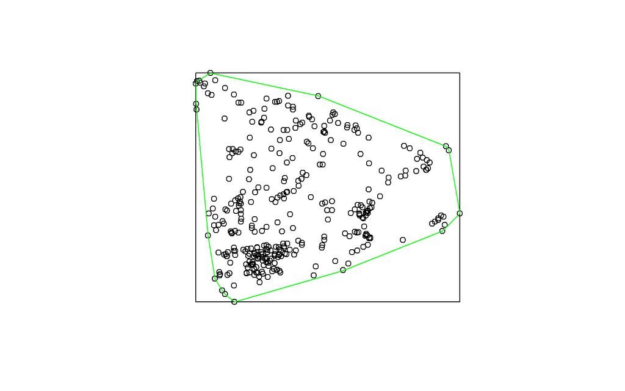

```r
# Make a simple feature
library(sf)
inscription_spain <- inscription_spain %>%
    filter(!is.na(longitude)) %>%
    st_as_sf(coords = c("longitude", "latitude"), crs = 4326) %>%
    st_transform(3035)

ch <- st_buffer(st_convex_hull(st_union(inscription_spain)), 100)
b <- st_make_grid(inscription_spain, n = 1)
plot(inscription_spain$geometry)
plot(b, add = T)
plot(ch, border = "green", add = T)
```

# Start Spatial Segregation

Before attempting any spatial analysis, we need to convert data for Spain into a ppp object

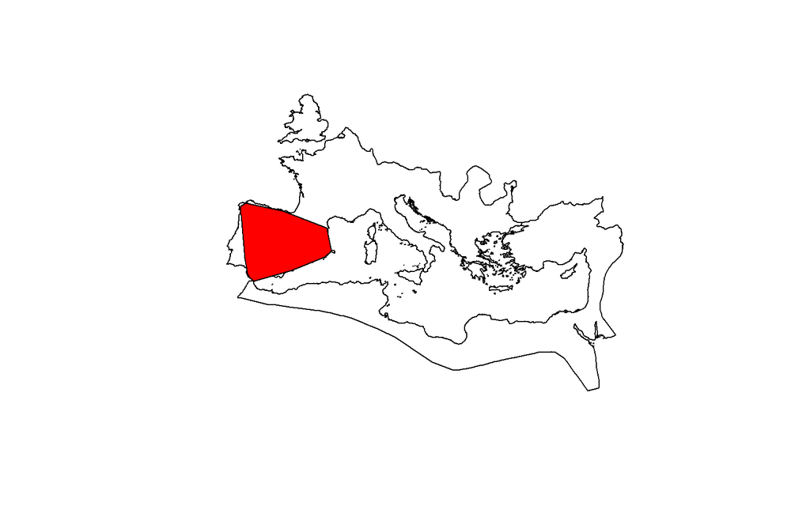

```r
# Libraries
library(spatstat)
library(spatialkernel)

# Data
pts <- as.matrix(st_coordinates(inscription_spain))
marks <- inscription_spain[["form_dis_manibus"]]

# Window
REbuff <- st_buffer(RE, 500)
plot(REbuff)
plot(ch, col = "red", add = T)
```

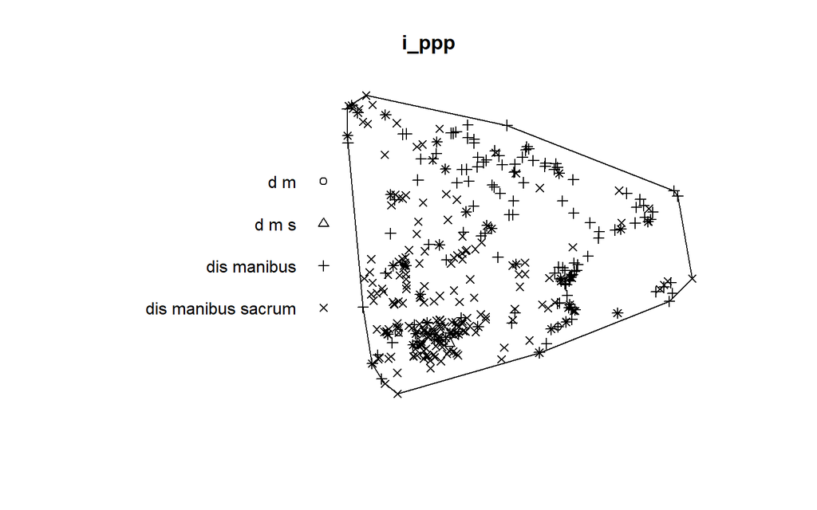

```r
# w <- as.owin(as_Spatial(st_sf(ch))) # does not work on school Dell, try the
# line below
w <- as.owin(st_sf(ch))  # does work

# density
library(maptools)
i_ppp <- as.ppp(pts, W = w)
marks(i_ppp) <- as.factor(marks)
plot(i_ppp)
```

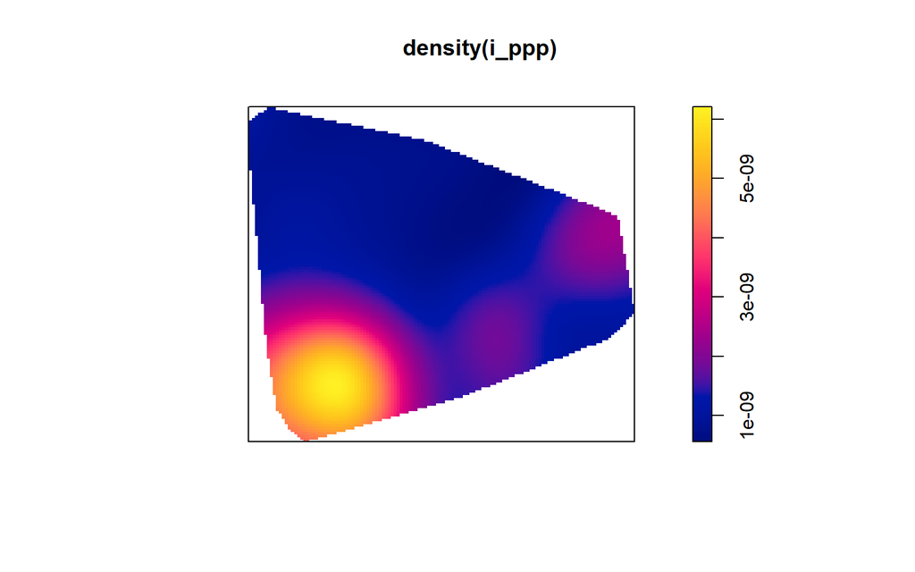

```r
plot(density(i_ppp))
```

## Basic density of Spanish formulae split by type Here we create an `spp`, a split marked spatial pattern. The spatstat library will now read the type of formula column as a factor and group by it for the purpose of all visualisations and computations.

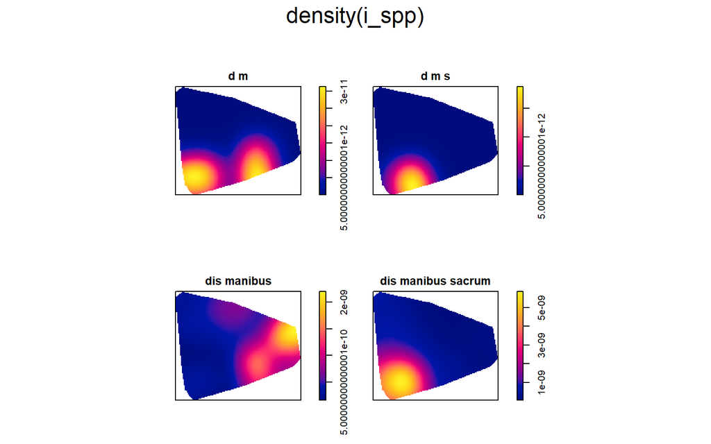

```r
i_spp <- split(i_ppp)
plot(density(i_spp))
```

## Look for optimal bandwidth for a kernel

```r
# Scan from 1000m to 10000m in steps of 1000m
`?`(spseg())

bw_choice <- spatialkernel::spseg(pts, marks, h = seq(1000, 1e+05, by = 1000), opt = 1)
```

```
Calculating cross-validated likelihood function
```

```r
# Plot the results and highlight the best bandwidth plotcv(bw_choice); abline(v
# = bw_choice$hcv, lty = 2, col = 'red') # it does not want to plot

# Print the best bandwidth
print(bw_choice$hcv)  # 6000m
```

```
[1] 6000
```

While the `plotcv()` will not plot the range of bandwiths and their impact on the segregation, the best choice `hcv` is 6000m in the case of Spanish inscriptions with formulae.

# Task 3: DM formula proportion estimation in a given environment

```
[1] "dis manibus sacrum" "dis manibus"        "d m"
[4] "d m s"
```

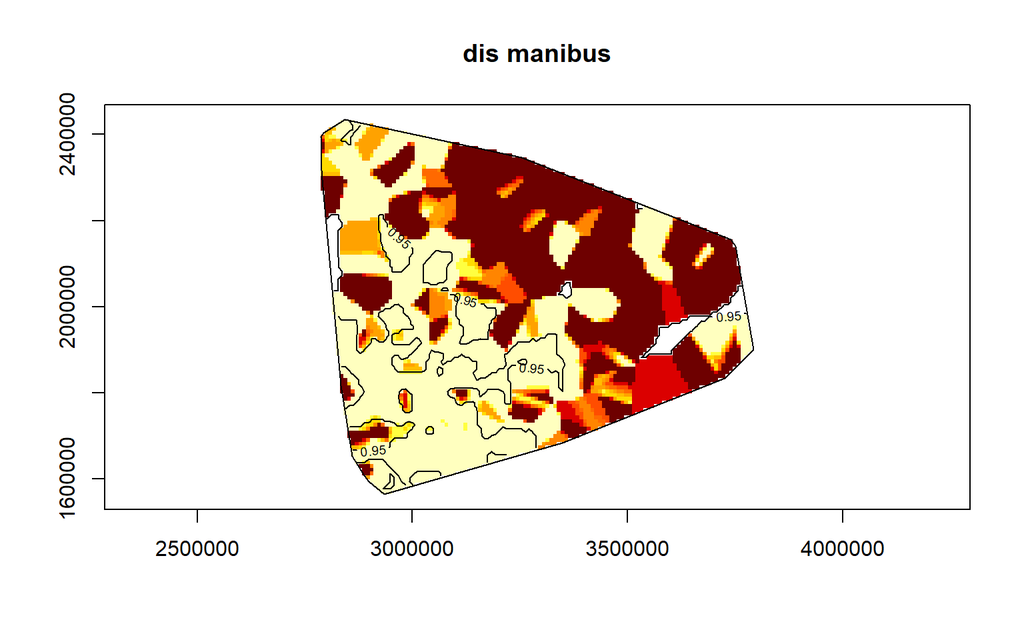

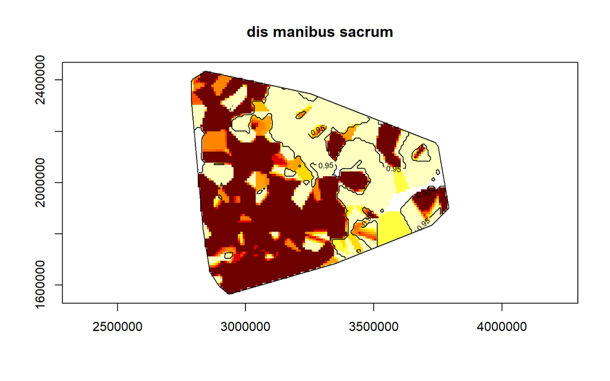

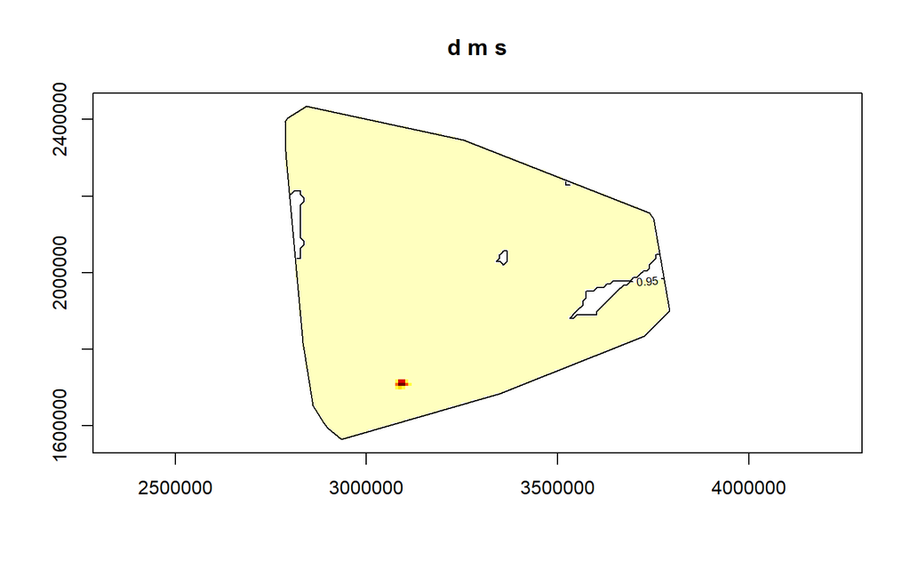

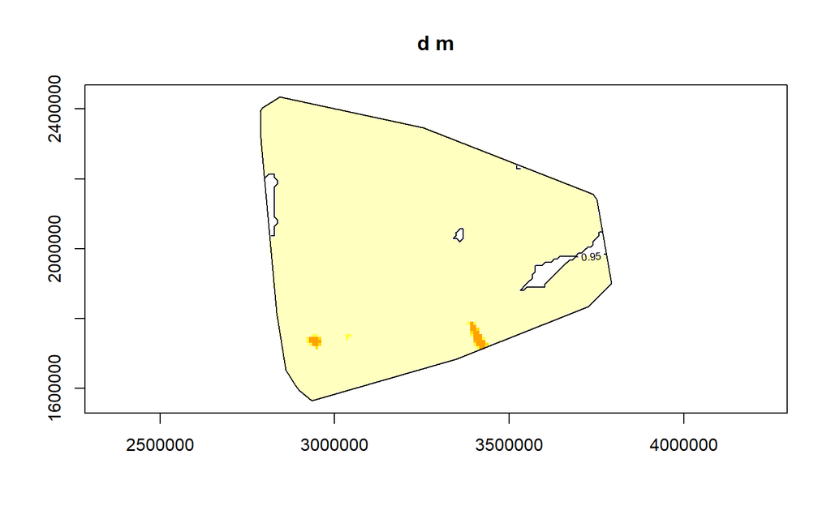

Good work! The simulation shows that long version of dis manibus sacrus is relatively more frequent in the south of Spain, while dis manibus has a higher proportion in the north.

# Task 4: DM Segregation- Mapping segregation

With a base map and some image and contour functions we can display both the probabilities and the significance tests over the area with more control than the `plotmc()` function.

This process may seem complex, but remember that with R you can always write functions to perform complex tasks and those you may repeat often. For example, to help with the mapping in this exercise you will create a function that builds a map from four different items.

## Instructions

- Inspect the segregation object.
  - Use `str()` to see the structure of `seg`.
  - Set `ncol` as the length of one of the elements of `seg`.
- Create prob_violent as a list with
  - x as the gridx element of `seg`.
  - y as the gridy element.
  - z as a matrix with the “dis manibus” column of the p element.
- Create `p_value` as in the previous step, except that the `z` element is logical, and `TRUE` when the `stpvalue` element of seg is less than 0.05.
- Call the `segmap()` function shown in the script to find areas where the probability of a crime being violent is above 0.15. Use 0.05 as the lower probability.

```
List of 11
 $ pvalue  : num 0.1
 $ stpvalue: num [1:11500, 1:4] NA NA NA NA NA NA NA NA NA NA ...
  ..- attr(*, "dimnames")=List of 2
  .. ..$ : NULL
  .. ..$ : chr [1:4] "dis manibus sacrum" "dis manibus" "d m" "d m s"
 $ ntest   : num 10
 $ gridx   : num [1:115] 2792316 2801016 2809717 2818418 2827119 ...
 $ gridy   : num [1:100] 1568169 1576870 1585571 1594272 1602973 ...
 $ p       : num [1:11500, 1:4] NA NA NA NA NA NA NA NA NA NA ...
  ..- attr(*, "dimnames")=List of 2
  .. ..$ : NULL
  .. ..$ : chr [1:4] "d m" "d m s" "dis manibus" "dis manibus sacrum"
 $ pts     : num [1:1013, 1:2] 2981218 3050933 3666528 2906721 3060134 ...
  ..- attr(*, "dimnames")=List of 2
  .. ..$ : chr [1:1013] "1" "2" "3" "4" ...
  .. ..$ : chr [1:2] "X" "Y"
 $ marks   : chr [1:1013] "dis manibus sacrum" "dis manibus sacrum" "dis manibus sacrum" "dis manibus sacrum" ...
 $ h       : num 6000
 $ opt     : num 3
 $ poly    : num [1:136, 1:2] 2934739 2934734 2934729 2934724 2934719 ...
  ..- attr(*, "dimnames")=List of 2
  .. ..$ : NULL
  .. ..$ : chr [1:2] "X" "Y"
```

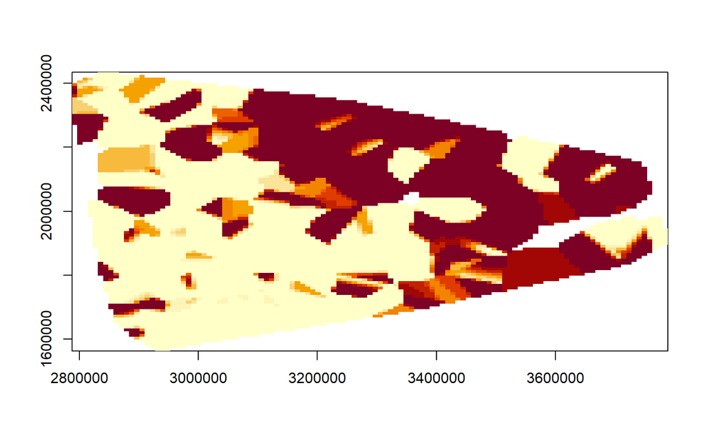

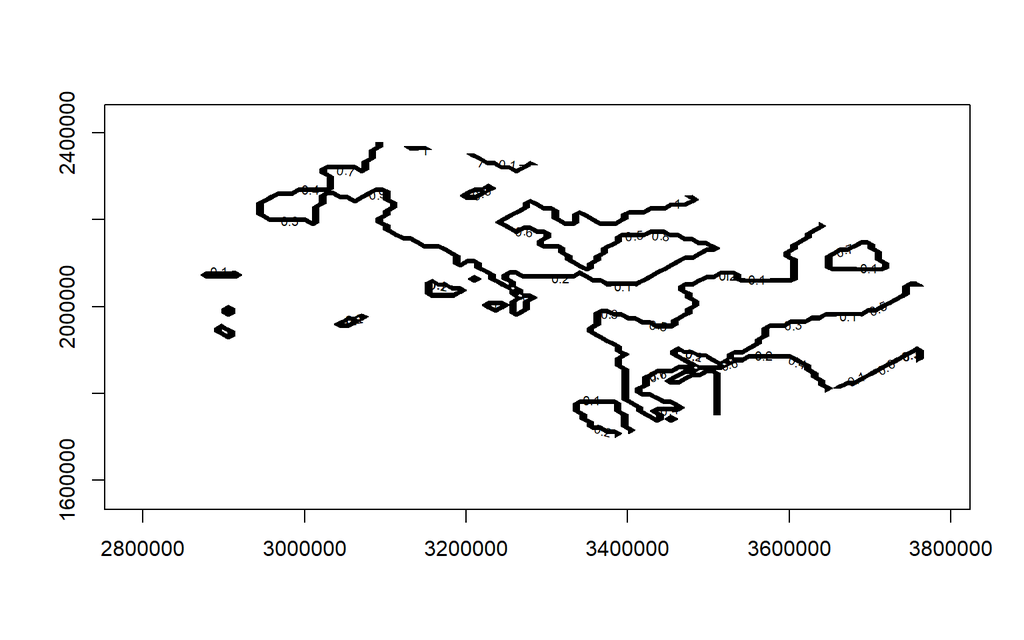

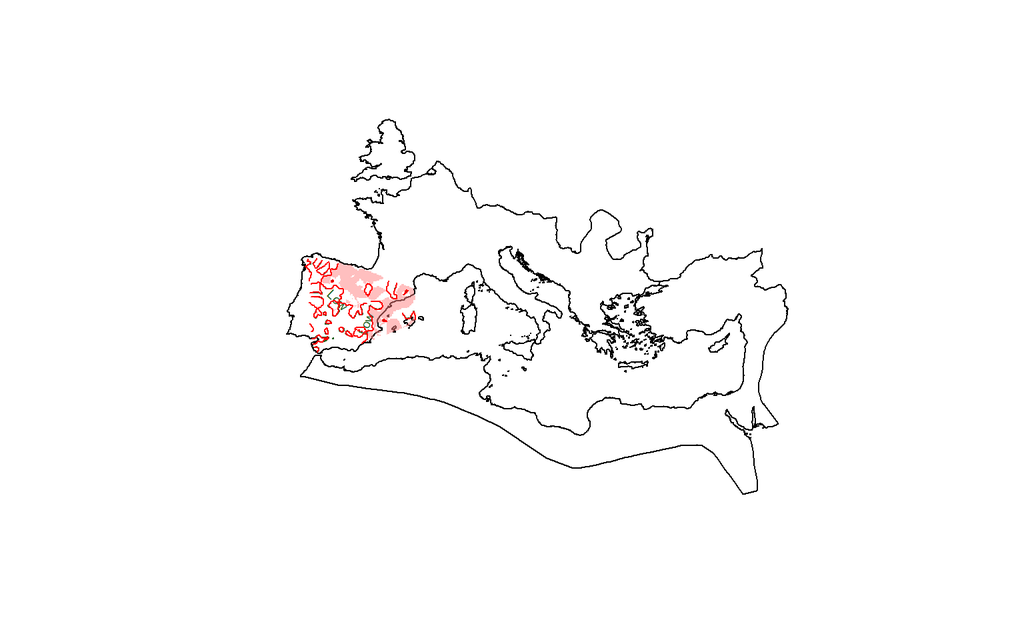

```
List of 11
 $ pvalue  : num 0.1
 $ stpvalue: num [1:11500, 1:4] NA NA NA NA NA NA NA NA NA NA ...
  ..- attr(*, "dimnames")=List of 2
  .. ..$ : NULL
  .. ..$ : chr [1:4] "dis manibus sacrum" "dis manibus" "d m" "d m s"
 $ ntest   : num 10
 $ gridx   : num [1:115] 2792316 2801016 2809717 2818418 2827119 ...
 $ gridy   : num [1:100] 1568169 1576870 1585571 1594272 1602973 ...
 $ p       : num [1:11500, 1:4] NA NA NA NA NA NA NA NA NA NA ...
  ..- attr(*, "dimnames")=List of 2
  .. ..$ : NULL
  .. ..$ : chr [1:4] "d m" "d m s" "dis manibus" "dis manibus sacrum"
 $ pts     : num [1:1013, 1:2] 2981218 3050933 3666528 2906721 3060134 ...
  ..- attr(*, "dimnames")=List of 2
  .. ..$ : chr [1:1013] "1" "2" "3" "4" ...
  .. ..$ : chr [1:2] "X" "Y"
 $ marks   : chr [1:1013] "dis manibus sacrum" "dis manibus sacrum" "dis manibus sacrum" "dis manibus sacrum" ...
 $ h       : num 6000
 $ opt     : num 3
 $ poly    : num [1:136, 1:2] 2934739 2934734 2934729 2934724 2934719 ...
  ..- attr(*, "dimnames")=List of 2
  .. ..$ : NULL
  .. ..$ : chr [1:2] "X" "Y"
```

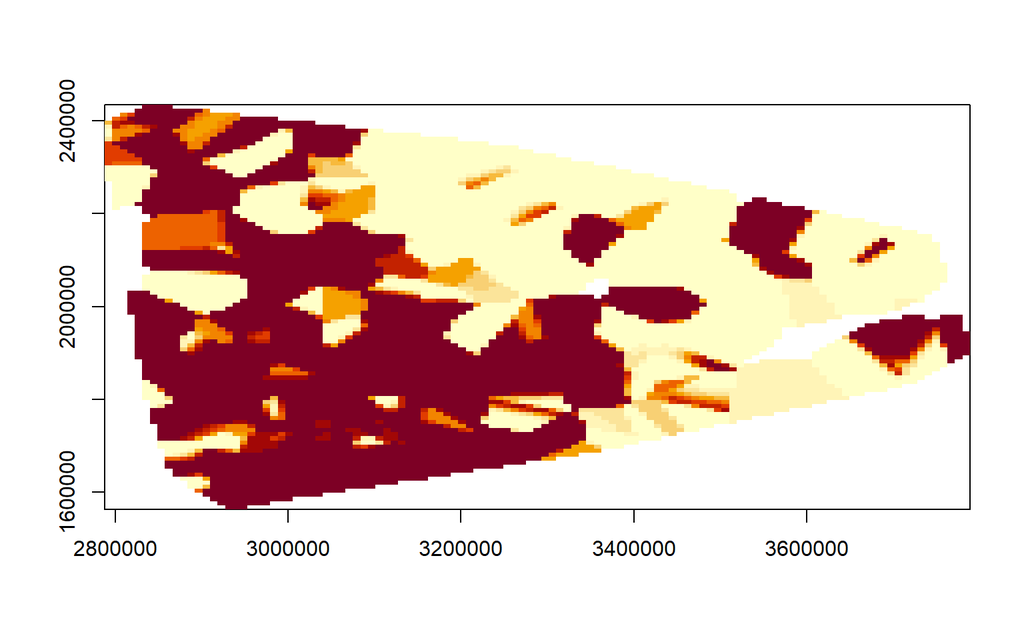

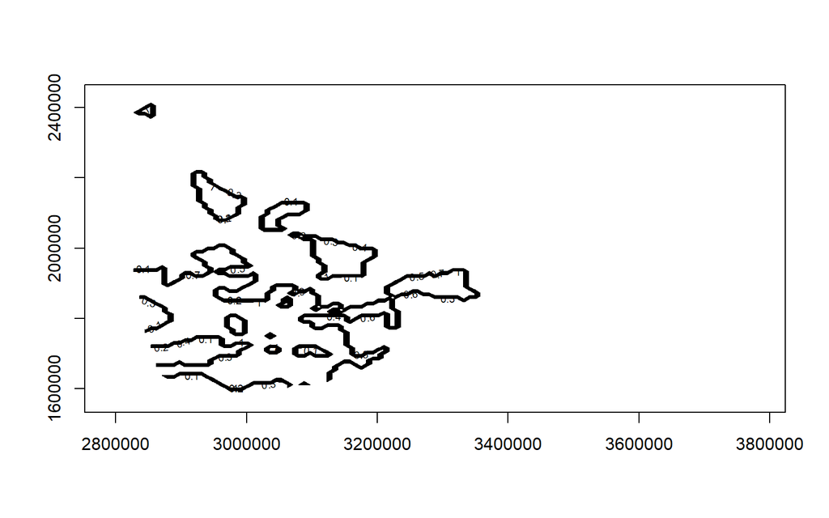

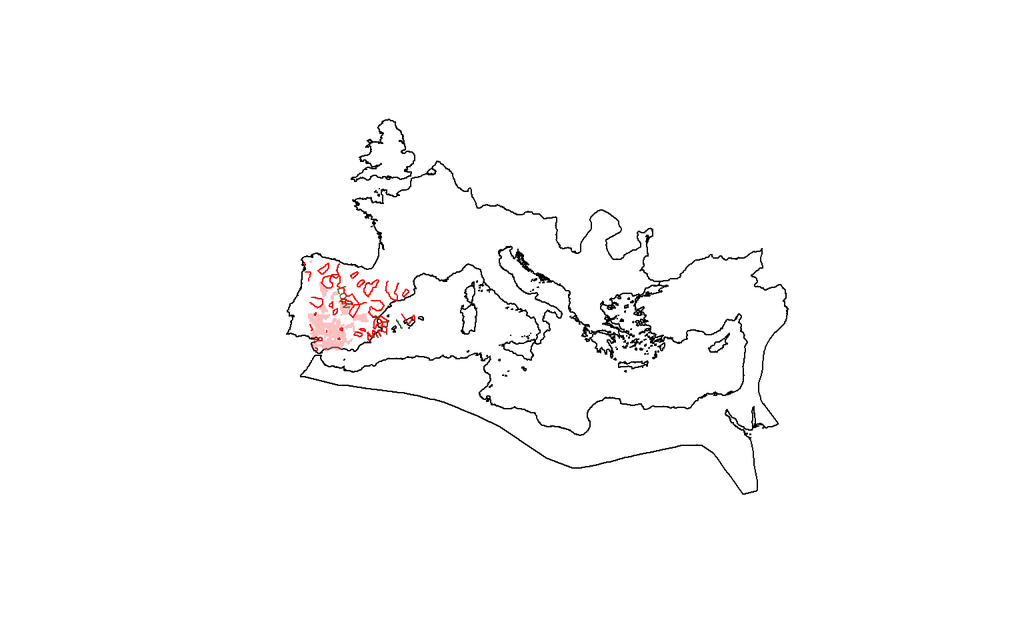

# Task 5: Dissimilarity index

```
 [1] "d m"                 "d m s"               NA
 [4] "dis manibus"         "diis manibus"        "dis manibus sacrum"
 [7] "dii manes"           "diis manibus sacrum" "di manis"
[10] "di manes"
```

```
[1] "dis manibus"         "dis manibus sacrum"  "diis manibus"
[4] "dii manes"           "diis manibus sacrum" "di manes"
```

```
[1] "dis manibus"         "dis manibus sacrum"  "diis manibus"
[4] NA                    "diis manibus sacrum"
```

```
    Reardon and O'Sullivan's spatial segregation measures

Dissimilarity (D)     : 0.781
Relative diversity (R): 0.63
Information theory (H): 0.574
Exposure/Isolation (P):
                 dismanibus dismanibussacrum  dimanes
dismanibus            0.906           0.0942 3.12e-04
dismanibussacrum      0.275           0.7250 8.16e-05
dimanes               0.891           0.0799 2.87e-02
--
The exposure/isolation matrix should be read horizontally.
Read 'help(spseg)' for more details.
```

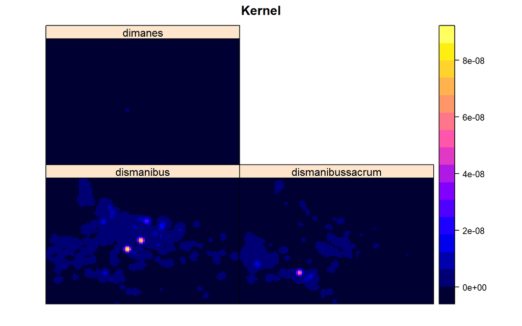

D is a measure of how different the composition of individual’s local environments are , on average, from the composition of the population as a whole. R is a measure of how much less diverse individuals’ local environments are, on average, than is the total population of region R. It is based on spatially-weighted interaction index of population diversity (near locations contribute more than distant locations - distance-decay approach). H is an aspatial measure of how much less diverse individuals’ local environments are, on average, than is the total population of region R (entropy of local and overall environment). 1 indicates maximum segregation, - when each indviduals’ local environment is monoracial, for example. 0 indicates complete integration, when each individual’s local environment has the same racial composition as the total population.

P spatial exposure of one group to another in local environment. Spatial isolation is the spatial exposure of group to itself

# Task 6: Spatial clustering

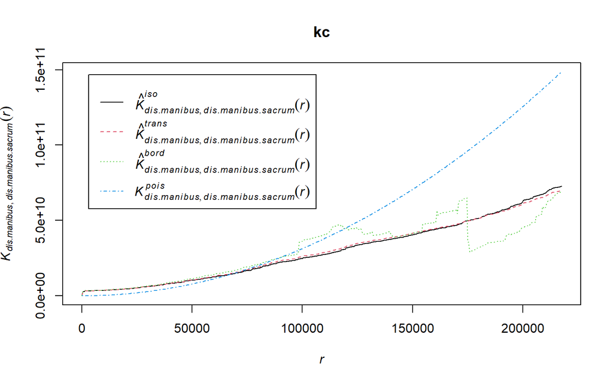

```r
kc <- Kcross(i_ppp, i = "dis manibus", j = "dis manibus sacrum")
plot(kc)
```

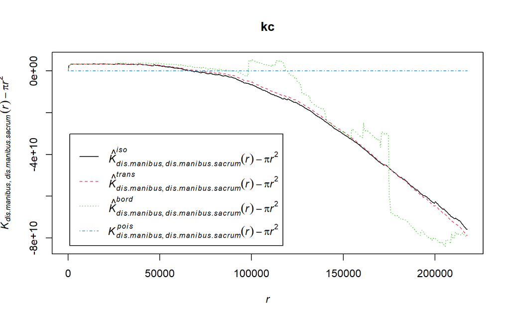

```r
plot(kc, . - pi * r^2 ~ r)
```

This chart shows that the dis manibus and dis manibus sacrum formulae are clustered at short distances up to 50km and then dispersed, unless we consider border effects (green dotted line)

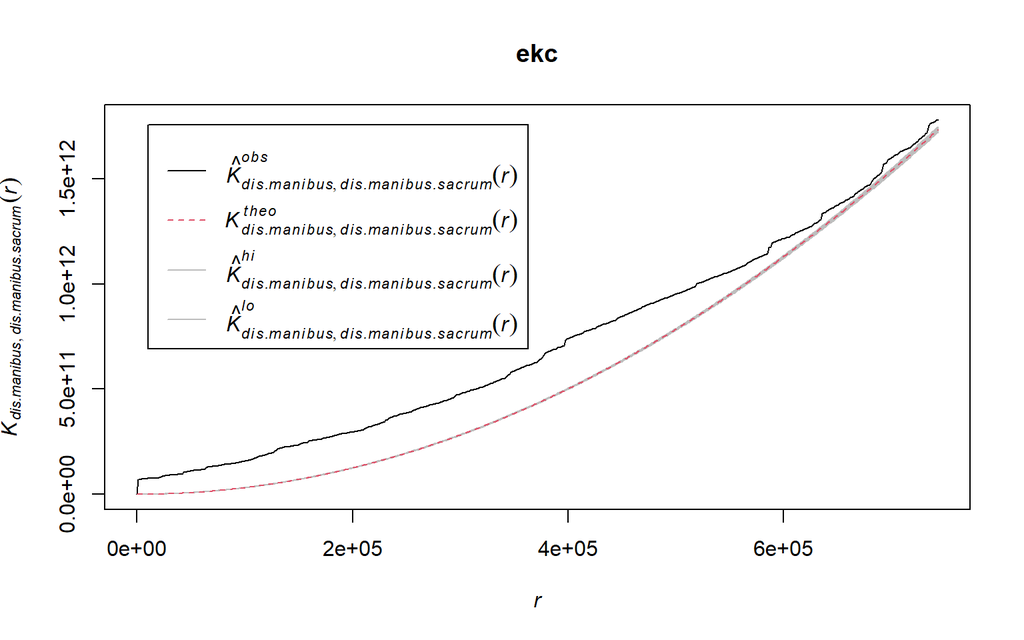

```r
# ekc <- envelope(i_ppp, Kcross, nsim = 50, i = 'dis manibus', j = 'dis manibus
# sacrum')
ekc <- readRDS("../data/DMekc.rds")
plot(ekc)
```

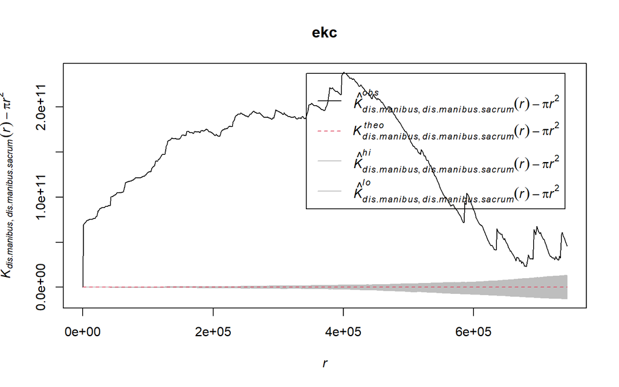

```r
plot(ekc, . - pi * r^2 ~ r)
```

```r
saveRDS(ekc, "../data/DMekc.rds")
```

If we calculate an envelope of confidence, all the DM and DMS formulae are mutually clustered compared to the random distribution that one would anticipate. However at the scale of 200-600km this is not super-helpful. We need smaller more regional datasets.

# Task 7: Start working with time

Let’s break up the RE inscriptions by century

```r
# Download json for 1st c CE

library(jsonlite)
# First century
download.file("https://sciencedata.dk/public/b6b6afdb969d378b70929e86e58ad975/formulae/EDH_DM_1CAD.json",
    "../data/EDH_DM1.json")
list_json <- jsonlite::fromJSON("../data/EDH_DM1.json")
CenturyOne <- as_tibble(list_json)

# Second century
download.file("https://sciencedata.dk/public/b6b6afdb969d378b70929e86e58ad975/formulae/EDH_DM_2CAD.json",
    "../data/EDH_DM2.json")
list_json <- jsonlite::fromJSON("../data/EDH_DM2.json")
CenturyTwo <- as_tibble(list_json)

# Third century
download.file("https://sciencedata.dk/public/b6b6afdb969d378b70929e86e58ad975/formulae/EDH_DM_3CAD.json",
    "../data/EDH_DM3.json")
list_json <- jsonlite::fromJSON("../data/EDH_DM3.json")
CenturyThree <- as_tibble(list_json)


# Inspect
names(CenturyOne)
```

```
 [1] "id"
 [2] "longitude"
 [3] "latitude"
 [4] "type_of_inscription_clean"
 [5] "height_cm"
 [6] "width_cm"
 [7] "depth_cm"
 [8] "material_clean"
 [9] "type_of_monument_clean"
[10] "province_label_clean"
[11] "country_clean"
[12] "findspot_ancient_clean"
[13] "clean_text_conservative"
[14] "clean_text_interpretive_word"
[15] "clean_text_interpretive_word_lowercase"
[16] "form_dis_manibus"
[17] "random_dates"
[18] "date_var_1"
```

```r
# CenturyOne$random_dates
CenturyOne$date_var_1  # first list of random generated dates from use span interval
```

```
 [1]  58  96  67 100  48  93  93  58  80  84  99  98  72  91  55  81  85  91  68
[20]  84  19  88  80  79 100  78  80  77  57  88  93  83  80  74  31  87  86  74
[39]  98  75  61  84  99  77  75  94  71  92  89  79  51  92  90  30  75  65  78
[58]  94  98  86  82  84  72  84  96  65  90  45  78  73  72  82   4  77  10
 [ reached getOption("max.print") -- omitted 360 entries ]
```

```r
# Spatialize
i1 <- inscriptions %>%
    filter(id %in% CenturyOne$id)  # 7 fewer than in CenturyOne

i2 <- inscriptions %>%
    filter(id %in% CenturyTwo$id)  # over 200 ids fewer
length(which(duplicated(CenturyTwo$id)))
```

```
[1] 0
```

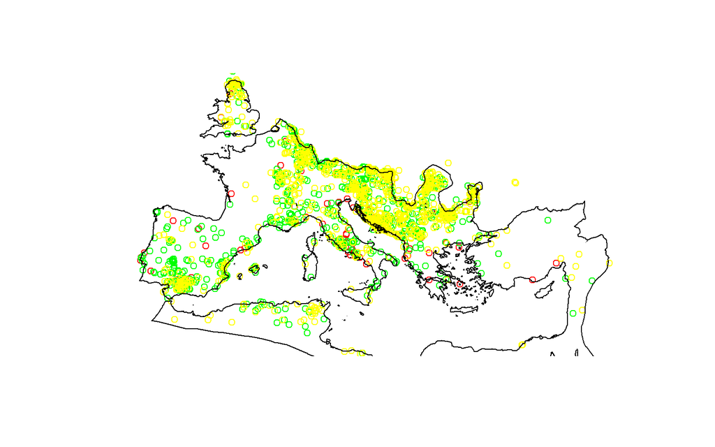

```r
i3 <- inscriptions %>%
    filter(id %in% CenturyThree$id)  # 2000 missing


# Alternative spatialisation
i1 <- CenturyOne %>%
    filter(!is.na(latitude)) %>%
    st_as_sf(coords = c("longitude", "latitude"), crs = 4326) %>%
    st_transform(3035)

i2 <- CenturyTwo %>%
    filter(!is.na(latitude)) %>%
    st_as_sf(coords = c("longitude", "latitude"), crs = 4326) %>%
    st_transform(3035)

i3 <- CenturyThree %>%
    filter(!is.na(latitude)) %>%
    st_as_sf(coords = c("longitude", "latitude"), crs = 4326) %>%
    st_transform(3035)

plot(i1$geometry, col = "red")
plot(i2$geometry, col = "green", add = T)
plot(i3$geometry, col = "yellow", add = T)
plot(RE, add = T)
```

# Task 8: DM segregation results in century-slices

My expectation is for higher values of segregation-isolation as aggregation will increase diversity.

## First century

```r
i1_data <- i1 %>%
    dplyr::mutate(dismanibus = case_when(form_dis_manibus == "di manes" ~ 0, form_dis_manibus ==
        "dii manes" ~ 0, form_dis_manibus == "dis manibus" ~ 1, form_dis_manibus ==
        "diis manibus" ~ 1, form_dis_manibus == "dis manibus sacrum" ~ 0, form_dis_manibus ==
        "diis manibus sacrum" ~ 0), dismanibussacrum = case_when(form_dis_manibus ==
        "di manes" ~ 0, form_dis_manibus == "dii manes" ~ 0, form_dis_manibus ==
        "dis manibus" ~ 0, form_dis_manibus == "diis manibus" ~ 0, form_dis_manibus ==
        "dis manibus sacrum" ~ 1, form_dis_manibus == "diis manibus sacrum" ~ 1),
        dimanes = case_when(form_dis_manibus == "di manes" ~ 1, form_dis_manibus ==
            "dii manes" ~ 1, form_dis_manibus == "dis manibus" ~ 0, form_dis_manibus ==
            "diis manibus" ~ 0, form_dis_manibus == "dis manibus sacrum" ~ 0, form_dis_manibus ==
            "diis manibus sacrum" ~ 0)) %>%
    dplyr::select(dismanibus, dismanibussacrum, dimanes) %>%
    st_drop_geometry()

# run the spseg() function
pp1 <- seg::spseg(x = st_coordinates(i1), data = i1_data, smoothing = "kernel", maxdist = 6000)

# Look at the results
print(pp1, digits = 3)
```

```
    Reardon and O'Sullivan's spatial segregation measures

Dissimilarity (D)     : 0.709
Relative diversity (R): 0.575
Information theory (H): 0.544
Exposure/Isolation (P):
                 dismanibus dismanibussacrum  dimanes
dismanibus            0.932           0.0651 0.002616
dismanibussacrum      0.349           0.6504 0.000831
dimanes               0.936           0.0556 0.008341
--
The exposure/isolation matrix should be read horizontally.
Read 'help(spseg)' for more details.
```

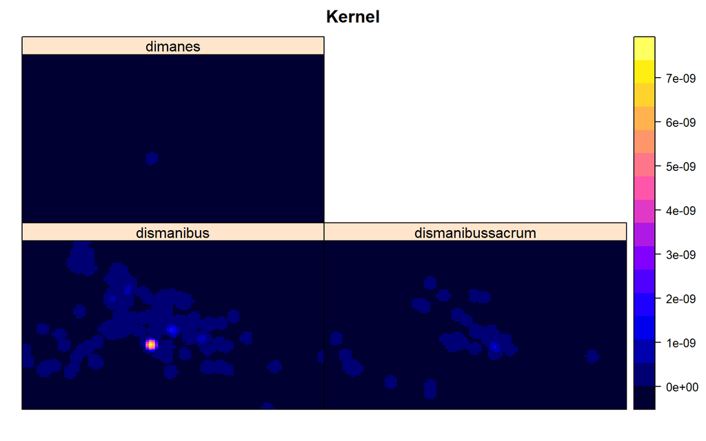

```r
spplot(pp1, main = "Kernel")
```

```r
help(spseg)
```

## Second century

```r
i2_data <- i2 %>%
    dplyr::mutate(dismanibus = case_when(form_dis_manibus == "di manes" ~ 0, form_dis_manibus ==
        "dii manes" ~ 0, form_dis_manibus == "dis manibus" ~ 1, form_dis_manibus ==
        "diis manibus" ~ 1, form_dis_manibus == "dis manibus sacrum" ~ 0, form_dis_manibus ==
        "diis manibus sacrum" ~ 0), dismanibussacrum = case_when(form_dis_manibus ==
        "di manes" ~ 0, form_dis_manibus == "dii manes" ~ 0, form_dis_manibus ==
        "dis manibus" ~ 0, form_dis_manibus == "diis manibus" ~ 0, form_dis_manibus ==
        "dis manibus sacrum" ~ 1, form_dis_manibus == "diis manibus sacrum" ~ 1),
        dimanes = case_when(form_dis_manibus == "di manes" ~ 1, form_dis_manibus ==
            "dii manes" ~ 1, form_dis_manibus == "dis manibus" ~ 0, form_dis_manibus ==
            "diis manibus" ~ 0, form_dis_manibus == "dis manibus sacrum" ~ 0, form_dis_manibus ==
            "diis manibus sacrum" ~ 0)) %>%
    dplyr::select(dismanibus, dismanibussacrum, dimanes) %>%
    st_drop_geometry()

# run the spseg() function
pp2 <- seg::spseg(x = st_coordinates(i2), data = i2_data, smoothing = "kernel", maxdist = 6000)

# Look at the results
print(pp2, digits = 3)
```

```
    Reardon and O'Sullivan's spatial segregation measures

Dissimilarity (D)     : 0.83
Relative diversity (R): 0.689
Information theory (H): 0.627
Exposure/Isolation (P):
                 dismanibus dismanibussacrum  dimanes
dismanibus            0.906           0.0936 4.10e-07
dismanibussacrum      0.217           0.7831 5.29e-07
dimanes               0.518           0.2886 1.93e-01
--
The exposure/isolation matrix should be read horizontally.
Read 'help(spseg)' for more details.
```

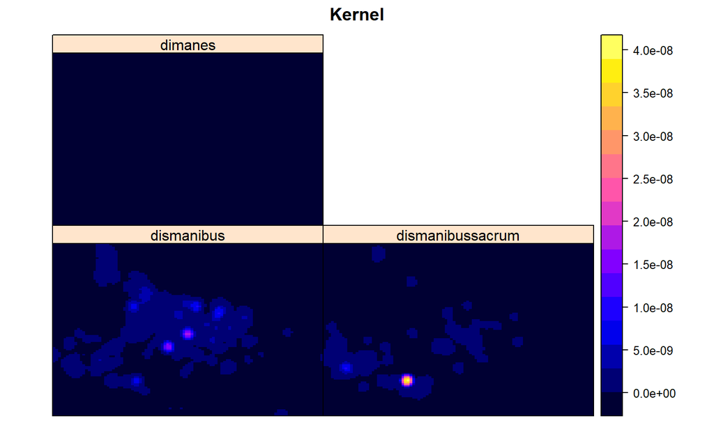

```r
spplot(pp2, main = "Kernel")
```

```r
help(spseg)
```

## Third century

```r
i3_data <- i3 %>%
    dplyr::mutate(dismanibus = case_when(form_dis_manibus == "di manes" ~ 0, form_dis_manibus ==
        "dii manes" ~ 0, form_dis_manibus == "dis manibus" ~ 1, form_dis_manibus ==
        "diis manibus" ~ 1, form_dis_manibus == "dis manibus sacrum" ~ 0, form_dis_manibus ==
        "diis manibus sacrum" ~ 0), dismanibussacrum = case_when(form_dis_manibus ==
        "di manes" ~ 0, form_dis_manibus == "dii manes" ~ 0, form_dis_manibus ==
        "dis manibus" ~ 0, form_dis_manibus == "diis manibus" ~ 0, form_dis_manibus ==
        "dis manibus sacrum" ~ 1, form_dis_manibus == "diis manibus sacrum" ~ 1),
        dimanes = case_when(form_dis_manibus == "di manes" ~ 1, form_dis_manibus ==
            "dii manes" ~ 1, form_dis_manibus == "dis manibus" ~ 0, form_dis_manibus ==
            "diis manibus" ~ 0, form_dis_manibus == "dis manibus sacrum" ~ 0, form_dis_manibus ==
            "diis manibus sacrum" ~ 0)) %>%
    dplyr::select(dismanibus, dismanibussacrum, dimanes) %>%
    st_drop_geometry()

# run the spseg() function
pp3 <- seg::spseg(x = st_coordinates(i3), data = i3_data, smoothing = "kernel", maxdist = 6000)

# Look at the results
print(pp3, digits = 3)
```

```
    Reardon and O'Sullivan's spatial segregation measures

Dissimilarity (D)     : 0.756
Relative diversity (R): 0.631
Information theory (H): 0.61
Exposure/Isolation (P):
                 dismanibus dismanibussacrum  dimanes
dismanibus            0.958         0.042134 2.91e-04
dismanibussacrum      0.325         0.674854 2.33e-06
dimanes               0.803         0.000832 1.96e-01
--
The exposure/isolation matrix should be read horizontally.
Read 'help(spseg)' for more details.
```

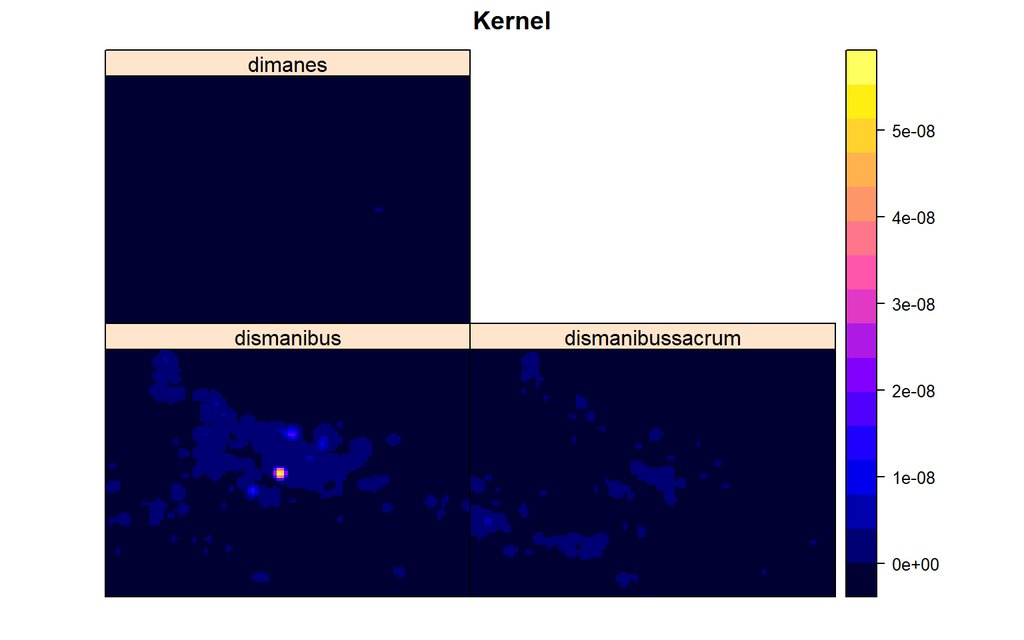

```r
spplot(pp3, main = "Kernel")
```